# RT-qPCR of pRPS3-mCh-tRPS3mod experimental replicate 1 (n=1)

Jamie Auxillos

23/01/2020

# Plan

Here, we are testing the impact of sequence motifs inserted into the 3’UTR on mRNA stability. RT-qPCR is used to measure the mRNA abundance of mCherry in each strain. The strains tested in this experiments contain a plasmid with an mCherrry cassette driven by pRPS3 and tRPS3, however the 3’UTRs are modified to incorporate different stability or decay motifs.

# Experimental information

The strains used here are pRPS3-mCherry-tRPS3 wild type (WT), pRPS3-mCherry-tRPS3 mod0 (mod0), pRPS3-mCherry-tRPS3 modA (modA), pRPS3-mCherry-tRPS3 modB (modB), pRPS3-mCherry-tRPS3 modC (modC), pRPS3-mCherry-tRPS3 modD (modD), pRPS3-mCherry-tRPS3 modE (modE), POT1-ccdb. For each strain, three biological replicates were grown. Strains were grown overnight to saturation in a deep well plate (200 ul) in a shaking incubator set at 250 rpm and at 30C. The next day, the OD600 of these cultures were measured and diluted down to an OD600 of 0.2 in an 8 ml culture in a 12 column deep well plate. The samples were grown to an OD600 of 0.5-0.6 for ~3-4 hours. 5 mls of the culture were harvested by centrifugation (3500 rpm for 3 minutes) in a 15 ml falcon tube. The cells were lysed and the RNA was extracted using the following RNA extraction protocol https://www.protocols.io/view/column-based-zymo-rna-extraction-bbcgiitw. The RNA was treated with DNase and used as the template for reverse transcription and qPCR using the following protocol https://github.com/ewallace/protocols/blob/master/RTqPCR_Agilent_Lightcycler_Protocol.md. We are using the probes mCh-7, URA3-ORF, RPS3-ORF and PGK1-ORF for the qPCR experiment. For each RNA sample, we have three technical replicates.

## Plate plan

```r
# list Targets /Probes
Probes <- c("mCh-7", "URA3-ORF", "RPS3-ORF", "PGK1-ORF")
Probesvalues <-factor(rep(Probes,levels=Probes))

Strainlevels <- c("pRPS3-tRPS3_WT","pRPS3-tRPS3_mod0","pRPS3-tRPS3_modA","pRPS3-tRPS3_modB","pRPS3-tRPS3_modC", "pRPS3-tRPS3_modD", "pRPS3-tRPS3_modE","POT1-ccdB")
Strainvalues <- factor(rep(Strainlevels,each=3),levels=Strainlevels)

BioReplevels <- c("BioRep1","BioRep2","BioRep3")
BioRepvalues <- factor(rep(BioReplevels,times=8),levels=BioReplevels)

colkey <- tibble(WellC=1:24,
                 Sample=Strainvalues,
                 BioRep=BioRepvalues)
rowkey <- create_rowkey_4in16(Probe=Probesvalues)

plateplan <-
    label_plate_rowcol(create_blank_plate(WellR = LETTERS[1:16],WellC=1:24),
                       rowkey,colkey)
```

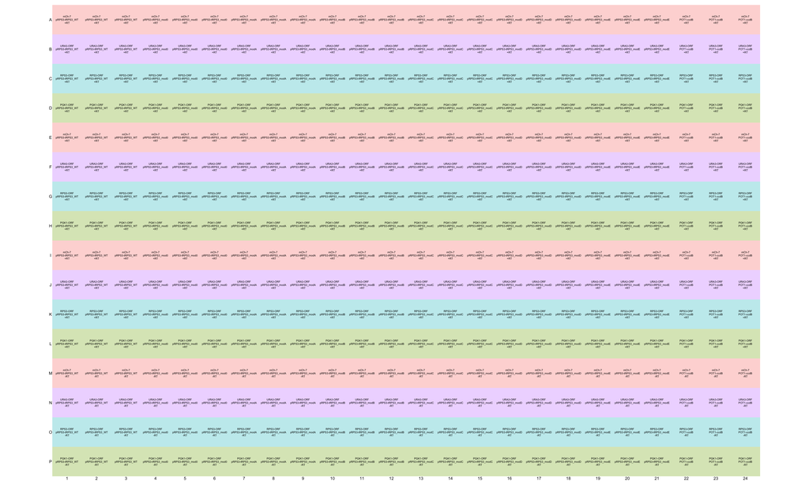

```r
display_plate( plateplan %>%
    mutate(Sample=Sample,BioRep) )
```

## Load plate and summarrise informatiion

Here, only one experimental replicate is loaded (n=1)

```r
# read my plates
plates <- read_tsv( "data/JA_20200121_tRPS3-200bp-n1-ct.txt",skip=1) %>%
    mutate(Well=Pos,Ct=Cp) %>%
    left_join(plateplan)
summary(plates)
```

```
##  Include            Color           Pos                Name
##  Mode:logical   Min.   :  255   Length:384         Length:384
##  TRUE:384       1st Qu.:  255   Class :character   Class :character
##                 Median :  255   Mode  :character   Mode  :character
##                 Mean   : 9399
##                 3rd Qu.:  255
##                 Max.   :65280
##
##        Cp        Concentration     Standard  Status            Well
##  Min.   : 8.97   Mode:logical   Min.   :0   Mode:logical   Length:384
##  1st Qu.:10.47   NA's:384       1st Qu.:0   NA's:384       Class :character
##  Median :10.96                  Median :0                  Mode  :character
##  Mean   :14.28                  Mean   :0
##  3rd Qu.:12.10                  3rd Qu.:0
##  Max.   :46.78                  Max.   :0
##  NA's   :54
##        Ct            WellR         WellC                  Sample
##  Min.   : 8.97   A      : 24   1      : 16   pRPS3-tRPS3_WT  :48
##  1st Qu.:10.47   B      : 24   2      : 16   pRPS3-tRPS3_mod0:48
##  Median :10.96   C      : 24   3      : 16   pRPS3-tRPS3_modA:48
##  Mean   :14.28   D      : 24   4      : 16   pRPS3-tRPS3_modB:48
##  3rd Qu.:12.10   E      : 24   5      : 16   pRPS3-tRPS3_modC:48
##  Max.   :46.78   F      : 24   6      : 16   pRPS3-tRPS3_modD:48
##  NA's   :54      (Other):240   (Other):288   (Other)         :96
##      BioRep     Type     TechRep      Probe
##  BioRep1:128   +RT:288   1:192   mCh-7   :96
##  BioRep2:128   -RT: 96   2: 96   PGK1-ORF:96
##  BioRep3:128             3: 96   RPS3-ORF:96
##                                  URA3-ORF:96
##
##
##
```

# Plotting the unnormalized data

All -RT controls have a high CT value and all +RT reactions have a low CT value. All BioRep and techrep for each strain (+RT) seems tight.

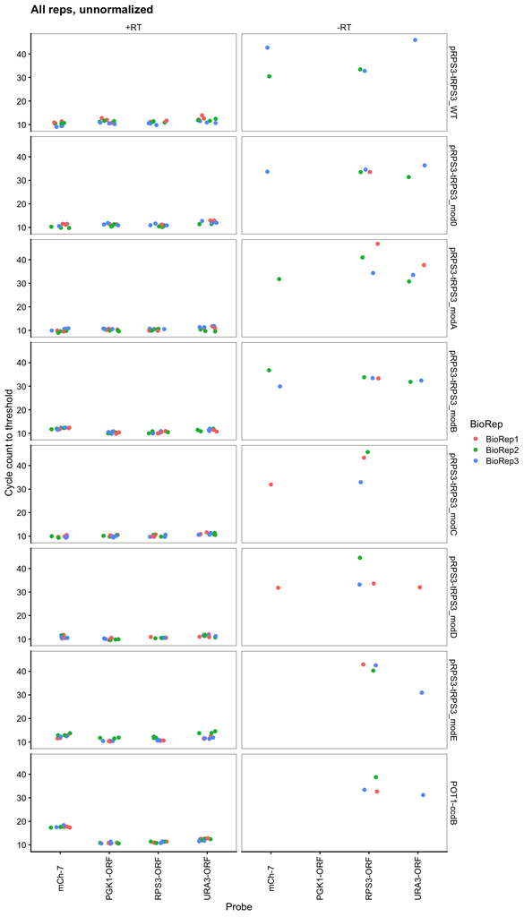

```r
ggplot(data=plates) +
    geom_point(aes(x=Probe,y=Ct,colour=BioRep),
               position=position_jitter(width = 0.2,height=0)) +
    labs(y="Cycle count to threshold",
         title="All reps, unnormalized") +
    scale_shape_manual(values=c(15:18,5:6)) +
    facet_grid(Sample~Type) +
    theme(axis.text.x=element_text(angle=90,vjust=0.5),
          panel.border=element_rect(fill = NA,linetype=1,
                                    colour = "grey50",size=0.5))
```

## Normalize Ct to PGK1, within Sample only

Here, i’m normalising the CT values of the mCh-7 probe by the detection by PGK1-ORF.

```r
platesnorm <- plates %>%
    filter(Type=="+RT") %>%
    normalizeqPCR(normProbes = "PGK1-ORF") %>%
    mutate(Sample = fct_relevel(Sample,
            "pRPS3-tRPS3_modC",
            "pRPS3-tRPS3_modE",
            "pRPS3-tRPS3_modD",
            "pRPS3-tRPS3_modA",
            "pRPS3-tRPS3_modB",
            "pRPS3-tRPS3_mod0",
            "pRPS3-tRPS3_WT",
            "POT1-ccdB"))%>%
filter(Probe=="mCh-7")

platesmed <- platesnorm %>%
      mutate(Sample = fct_relevel(Sample,
            "pRPS3-tRPS3_modC",
            "pRPS3-tRPS3_modE",
            "pRPS3-tRPS3_modD",
            "pRPS3-tRPS3_modA",
            "pRPS3-tRPS3_modB",
            "pRPS3-tRPS3_mod0",
            "pRPS3-tRPS3_WT",
            "POT1-ccdB"))%>%
      group_by(Sample,Probe,BioRep) %>%
filter(Probe=="mCh-7")%>%
    summarize(Ct=median(Value.norm,na.rm=TRUE),
              Abund=median(Value.normexp,na.rm=TRUE))
filter(platesmed,Probe=="PGK1-ORF")
```

```
## # A tibble: 0 x 5
## # Groups:   Sample, Probe [1]
## # … with 5 variables: Sample <fct>, Probe <fct>, BioRep <fct>, Ct <dbl>,
## #   Abund <dbl>
```

## Plotting all the normalised (to PGK1-ORF) Ct values for all biological replicates and technical replicates for each strain

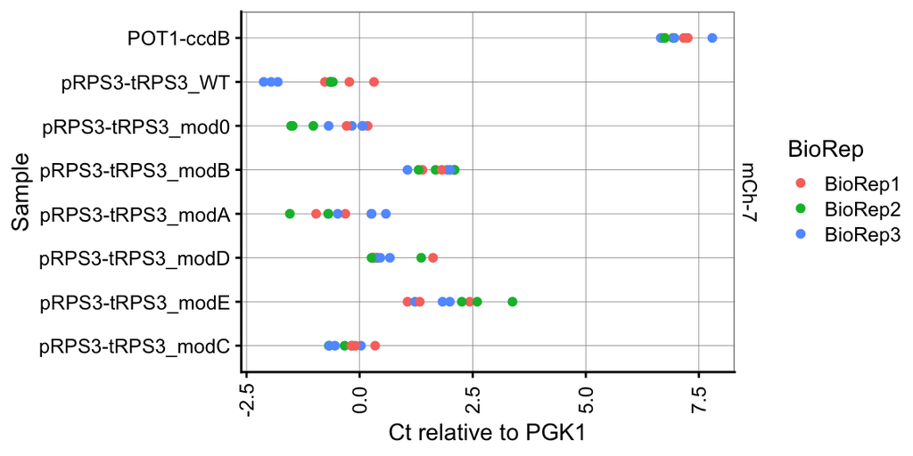

```r
ggplot(data=platesnorm) +
    geom_point(aes(x=Value.norm,y=Sample, colour=BioRep),
               position=position_jitter(width = 0.2,height=0)) +
    labs(x="Ct relative to PGK1") +
    scale_shape_manual(values=c(15:18,5:6)) +
    facet_grid(Probe~.) +
    theme(axis.text.x=element_text(angle=90,vjust=0.5),
          panel.grid.major = element_line(colour = "grey50",size=0.125))
```

## Plottting the mCherry mRNA detected in each strain (for biological replicates only)

-There doesn’t seem to be much difference between WT and mod0 -There isn’t an increase in mRNA abundance in the 3’UTR with an incorporated putative stability motif

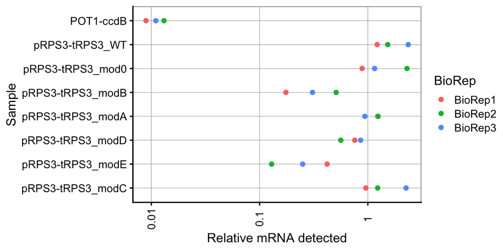

```r
ggplot(data=platesmed) +
    geom_point(aes(x=Abund,y=Sample,colour=BioRep),
               position=position_jitter(width = 0.2,height=0)) +
    scale_shape_manual(values=c(15:18,5:6)) +
    scale_x_log10nice("Relative mRNA detected") +
    theme(axis.text.x=element_text(angle=90,vjust=0.5),
         panel.grid.major = element_line(colour = "grey50",size=0.125))
```

## For plotting the melt curves and amplification curves

```r
platecurve <- read_tsv("data/JA_20200121_tRPS3-200bp-n1.txt",
                       skip=2,
                        col_names=c("Well","SID","Program","Segment",
                                    "Cycle","Time","Temperature","Fluor")
                      ) %>%
    debaseline() %>%
    left_join(plateplan) %>%
    mutate(BiolRep=1,Plate=1)
platecurve
```

```
## # A tibble: 84,864 x 19
##    Well  SID   Program Segment Cycle   Time Temperature Fluor  Base  Signal
##    <chr> <chr>   <dbl>   <dbl> <dbl>  <dbl>       <dbl> <dbl> <dbl>   <dbl>
##  1 A1    Samp…       2       2     1 233670        59.9  0.93  0.94 -0.0100
##  2 A1    Samp…       2       2     2 273130        59.8  0.94  0.94  0
##  3 A1    Samp…       2       2     3 312530        59.8  0.92  0.94 -0.0200
##  4 A1    Samp…       2       2     4 351930        59.8  0.94  0.94  0
##  5 A1    Samp…       2       2     5 391320        59.8  0.92  0.94 -0.0200
##  6 A1    Samp…       2       2     6 430720        59.8  0.93  0.94 -0.0100
##  7 A1    Samp…       2       2     7 470030        59.8  0.94  0.94  0
##  8 A1    Samp…       2       2     8 509520        59.8  0.94  0.94  0
##  9 A1    Samp…       2       2     9 549020        59.8  0.97  0.94  0.03
## 10 A1    Samp…       2       2    10 588420        59.8  0.99  0.94  0.05
## # … with 84,854 more rows, and 9 more variables: WellR <fct>, WellC <fct>,
## #   Sample <fct>, BioRep <fct>, Type <fct>, TechRep <fct>, Probe <fct>,
## #   BiolRep <dbl>, Plate <dbl>
```

```r
platesamp  <- platecurve %>% filter(Program == 2)

platesamp <- bind_rows(platecurve,platecurve) %>%
    filter(Program == 2)

platesmelt <- bind_rows(platecurve,platecurve) %>%
    filter(Program != 2) %>%
    getdRdTall() %>%
    filter(Temperature >= 61)
```

## Melt Curves of BioRep 1 samples

-RT seems to have a peak in the melt curve

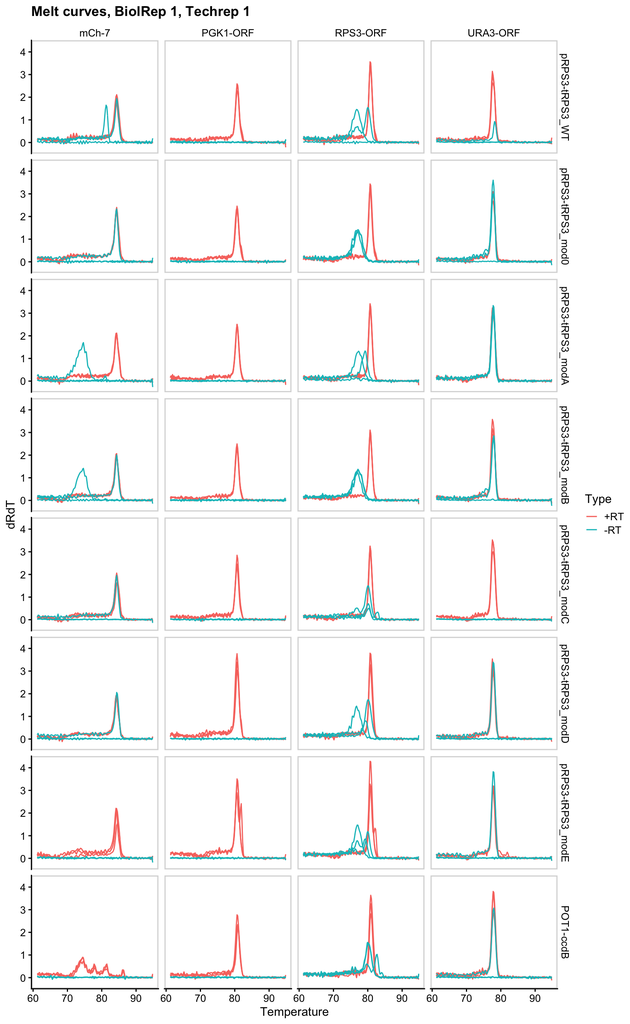

```r
ggplot(data=platesmelt %>%
           filter(TechRep==1,BiolRep==1),
       aes(x=Temperature,y=dRdT,colour=Type,group=Well)) +
    facet_grid(Sample~Probe) +
    geom_line() +
    scale_linetype_manual(values=c("-RT"="dashed","+RT"="solid")) +
    scale_x_continuous(breaks=seq(60,100,10),minor_breaks=seq(60,100,5)) +
    labs(title="Melt curves, BiolRep 1, Techrep 1") + panel_border()
```

## Amplification Curves of BioRep 1 samples

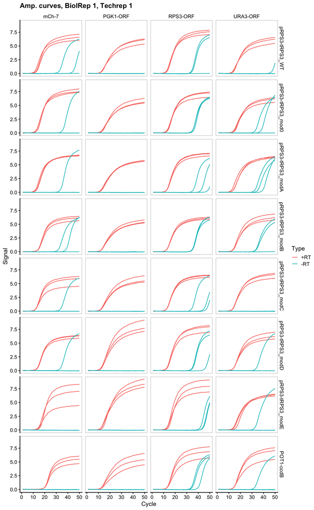

```r
ggplot(data=platesamp %>%
           filter(TechRep==1,BiolRep==1),
       aes(x=Cycle,y=Signal,colour=Type,group=Well)) +
    facet_grid(Sample~Probe) +
    geom_line() +
    scale_linetype_manual(values=c("-RT"="dashed","+RT"="solid")) +
    expand_limits(y=0) +
    labs(title="Amp. curves, BiolRep 1, Techrep 1") + panel_border()
```

## Moving forward

-a second experimental needs to be done to confirm this result -(Check with Sam and Edward)- an error appeared after knitting - “There were 50 or more warnings (use warnings() to see the first 50)”